# Sleep Health & Lifestyle Analysis

Author

William L.

## Background

Sleep health is a critical aspect of overall well-being, influencing both physical and mental health. Adequate sleep is quite essential for cognitive function, emotional regulation, and physical recovery. Various lifestyle factors, such as diet, physical activity, and stress levels, play significant roles in determining sleep quality and duration. Modern lifestyles, characterized by irregular sleep schedules, high stress, and sedentary behavior, often lead to sleep disturbances and disorders. Understanding the relationship between sleep and daily habits is crucial for developing effective interventions to improve sleep health.

## Unloading Packages

```r
library(tidyverse)
```

## Read File

```r
df <- read.csv("Sleep_health_and_lifestyle_dataset.csv")
glimpse(df)
```

```
Rows: 374
Columns: 13
$ Person.ID               <int> 1, 2, 3, 4, 5, 6, 7, 8, 9, 10, 11, 12, 13, 14,…
$ Gender                  <chr> "Male", "Male", "Male", "Male", "Male", "Male"…
$ Age                     <int> 27, 28, 28, 28, 28, 28, 29, 29, 29, 29, 29, 29…
$ Occupation              <chr> "Software Engineer", "Doctor", "Doctor", "Sale…
$ Sleep.Duration          <dbl> 6.1, 6.2, 6.2, 5.9, 5.9, 5.9, 6.3, 7.8, 7.8, 7…
$ Quality.of.Sleep        <int> 6, 6, 6, 4, 4, 4, 6, 7, 7, 7, 6, 7, 6, 6, 6, 6…
$ Physical.Activity.Level <int> 42, 60, 60, 30, 30, 30, 40, 75, 75, 75, 30, 75…
$ Stress.Level            <int> 6, 8, 8, 8, 8, 8, 7, 6, 6, 6, 8, 6, 8, 8, 8, 8…
$ BMI.Category            <chr> "Overweight", "Normal", "Normal", "Obese", "Ob…
$ Blood.Pressure          <chr> "126/83", "125/80", "125/80", "140/90", "140/9…
$ Heart.Rate              <int> 77, 75, 75, 85, 85, 85, 82, 70, 70, 70, 70, 70…
$ Daily.Steps             <int> 4200, 10000, 10000, 3000, 3000, 3000, 3500, 80…
$ Sleep.Disorder          <chr> "None", "None", "None", "Sleep Apnea", "Sleep …
```

## Descriptive Statistics

```r
summary(df)
```

```
   Person.ID         Gender               Age         Occupation
 Min.   :  1.00   Length:374         Min.   :27.00   Length:374
 1st Qu.: 94.25   Class :character   1st Qu.:35.25   Class :character
 Median :187.50   Mode  :character   Median :43.00   Mode  :character
 Mean   :187.50                      Mean   :42.18
 3rd Qu.:280.75                      3rd Qu.:50.00
 Max.   :374.00                      Max.   :59.00
 Sleep.Duration  Quality.of.Sleep Physical.Activity.Level  Stress.Level
 Min.   :5.800   Min.   :4.000    Min.   :30.00           Min.   :3.000
 1st Qu.:6.400   1st Qu.:6.000    1st Qu.:45.00           1st Qu.:4.000
 Median :7.200   Median :7.000    Median :60.00           Median :5.000
 Mean   :7.132   Mean   :7.313    Mean   :59.17           Mean   :5.385
 3rd Qu.:7.800   3rd Qu.:8.000    3rd Qu.:75.00           3rd Qu.:7.000
 Max.   :8.500   Max.   :9.000    Max.   :90.00           Max.   :8.000
 BMI.Category       Blood.Pressure       Heart.Rate     Daily.Steps
 Length:374         Length:374         Min.   :65.00   Min.   : 3000
 Class :character   Class :character   1st Qu.:68.00   1st Qu.: 5600
 Mode  :character   Mode  :character   Median :70.00   Median : 7000
                                       Mean   :70.17   Mean   : 6817
                                       3rd Qu.:72.00   3rd Qu.: 8000
                                       Max.   :86.00   Max.   :10000
 Sleep.Disorder
 Length:374
 Class :character
 Mode  :character
```

## Data Cleaning

```r
# Checking for NA Values
# Returns TRUE if there are NA values

is.na(df)
```

[output not shown]

#### Age Grouping

```r
age_group <- function(age) {
  if (age < 20) {
    return("Under 20")
  } else if (age >= 20 & age < 30) {
    return("20-30")
  } else if (age >= 30 & age < 40) {
    return("30-40")
  } else if (age >= 40 & age < 50) {
    return("40-50")
  } else if (age >= 50 & age < 60) {
    return("50-60")
  } else if (age >= 60 & age < 70) {
    return("60-70")
  } else {
    return(NA)
  }
}
```

```r
# New Column

df <- df |>
  mutate(age_group = sapply(Age, age_group))

head(df)
```

```
  Person.ID Gender Age           Occupation Sleep.Duration Quality.of.Sleep
1         1   Male  27    Software Engineer            6.1                6
2         2   Male  28               Doctor            6.2                6
3         3   Male  28               Doctor            6.2                6
4         4   Male  28 Sales Representative            5.9                4
5         5   Male  28 Sales Representative            5.9                4
6         6   Male  28    Software Engineer            5.9                4
  Physical.Activity.Level Stress.Level BMI.Category Blood.Pressure Heart.Rate
1                      42            6   Overweight         126/83         77
2                      60            8       Normal         125/80         75
3                      60            8       Normal         125/80         75
4                      30            8        Obese         140/90         85
5                      30            8        Obese         140/90         85
6                      30            8        Obese         140/90         85
  Daily.Steps Sleep.Disorder age_group
1        4200           None     20-30
2       10000           None     20-30
3       10000           None     20-30
4        3000    Sleep Apnea     20-30
5        3000    Sleep Apnea     20-30
6        3000       Insomnia     20-30
```

## Average Sleep Duration by Age:

There is a noticeable variation in average sleep duration across different ages. This suggests that sleep patterns might be influenced by age-factors such as lifestyle, work schedules, or health conditions.

#### Trends:

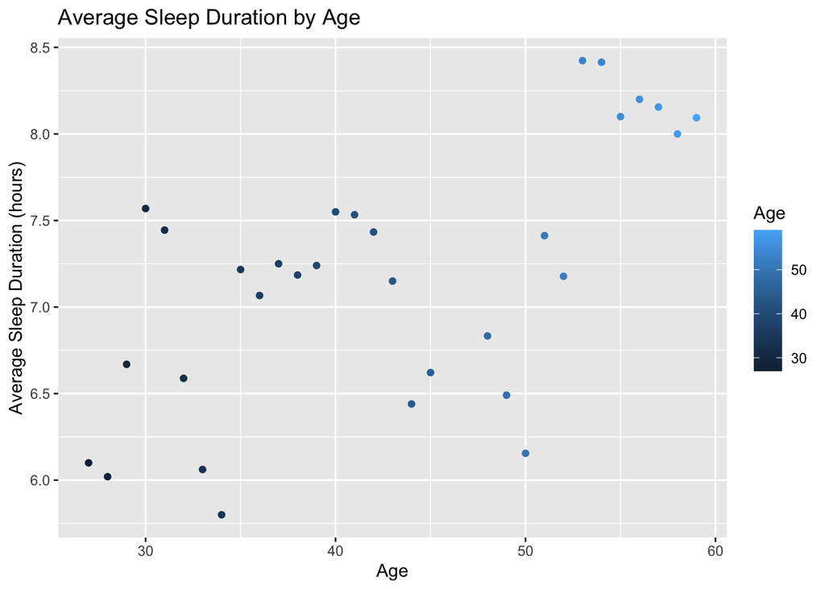

```r
average_sleep_duration <- df |>
  group_by(Age) |>
  summarize(
    count = n(),
    average_sleep_duration = mean(Sleep.Duration, na.rm = T)
  ) |>
  ggplot(aes(x = Age, y = average_sleep_duration, col = Age)) +
  geom_point() +
  labs(title = "Average Sleep Duration by Age",
       x = "Age",
       y = "Average Sleep Duration (hours)")

average_sleep_duration
```

## Physical Activity vs. Sleep Quality

There is a positive correlation between the quantitative variables. As physical activity levels increase, sleep quality has the tendency to improve.

This suggests that engaging in regular physical activity could be beneficial for enhancing sleep quality.

On the contrary, the data also shows a plateau at higher levels of physical activity, indicating that beyond a certain point, increased activity may not impact the quality of sleep.

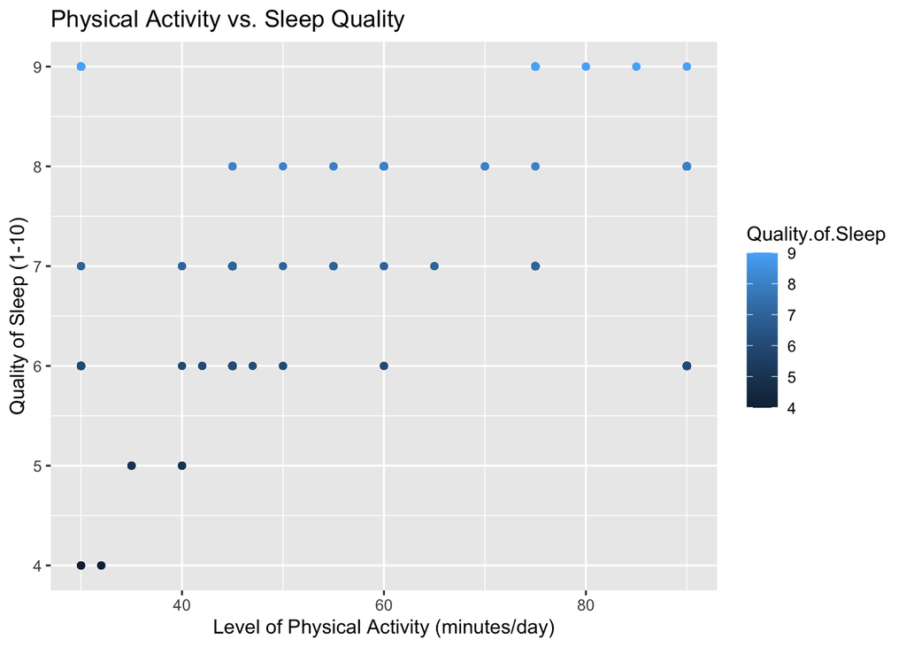

```r
ggplot(data = df, aes(x = Physical.Activity.Level, y = Quality.of.Sleep,
                      col = Quality.of.Sleep)) +
  geom_point() +
  labs(title = "Physical Activity vs. Sleep Quality",
       x = "Level of Physical Activity (minutes/day)",
       y = "Quality of Sleep (1-10)")
```

## Indicator Pertaining to Cardiovascular Health

#### Analyzation of Heart Rate Distribution

The normal heart rate range for adults is approximately 60-100 bpm. Majority of the individuals in the dataset has a heart rate within a healthy range.

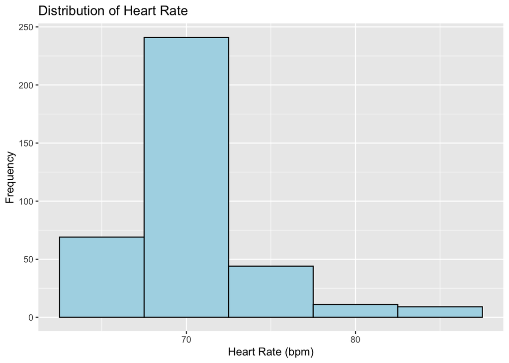

```r
ggplot(data = df, aes(x = Heart.Rate)) +
  geom_histogram(binwidth = 5, fill = "lightblue", color = "black") +
  labs(title = "Distribution of Heart Rate",
       x = "Heart Rate (bpm)",
       y = "Frequency")
```

#### Analyzation of Heart Rate by Gender

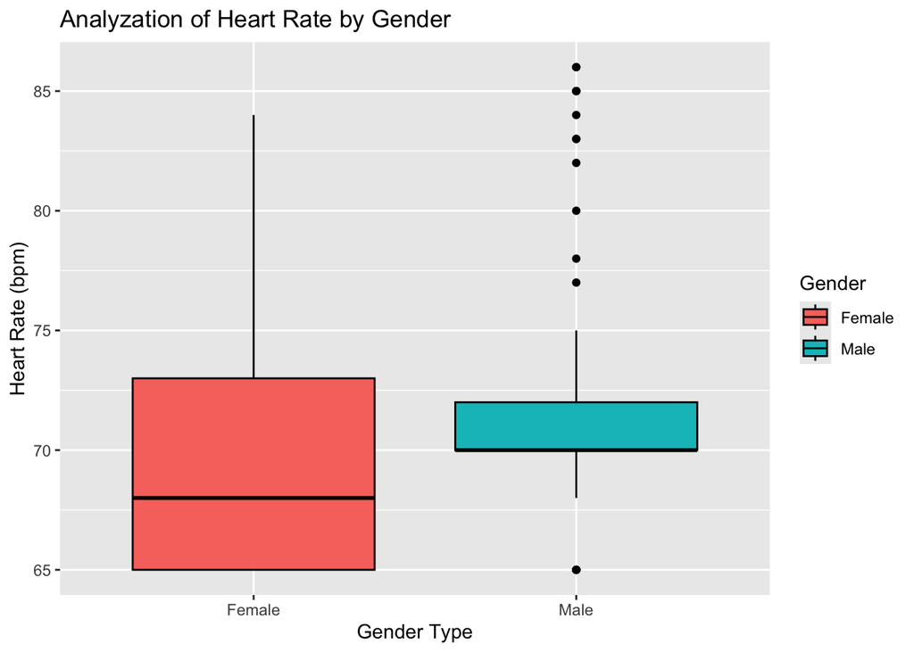

```r
ggplot(data = df, aes(x = Gender, y = Heart.Rate, fill = Gender)) +
  geom_boxplot(col = "black") +
  labs(title = "Analyzation of Heart Rate by Gender",
       x = "Gender Type",
       y = "Heart Rate (bpm)")
```

#### Analyzation of Heart Rate by Blood Pressure

The scatter plot indicates that an increase in systolic blood pressure is associated with higher heart rates. Individuals with high diastolic pressure often have high systolic pressure and heart rates.

- This portrayal is crucial for assessing cardiovascular health
- Upon analyzing the distribution of data points, individuals with high systolic and diastolic pressures along with high heart rates may require closer monitoring and medical intervention

```r
# Separating systolic and diastolic readings
df <- df |>
  separate(Blood.Pressure, into = c("systolic", "diastolic"), sep = "/") |>
  mutate(systolic = as.numeric(systolic),
         diastolic = as.numeric(diastolic))
```

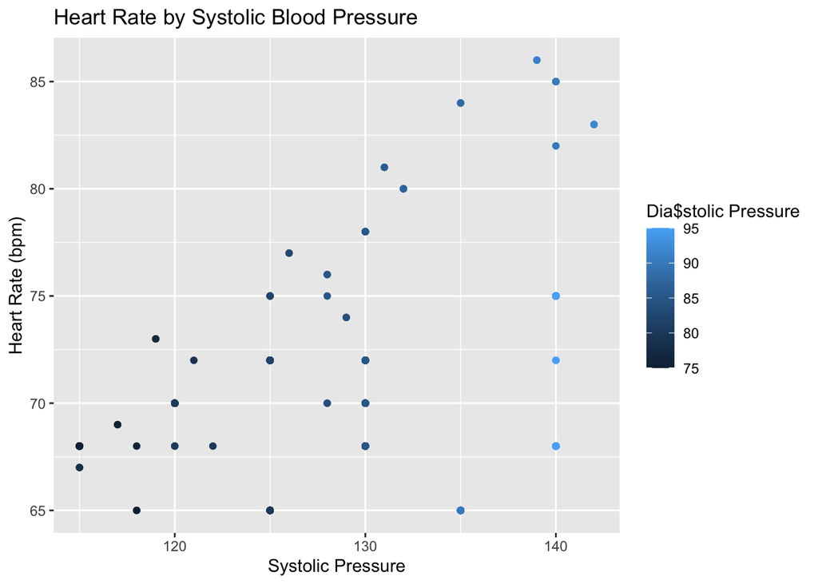

```r
ggplot(data = df, aes(x = systolic, y = Heart.Rate, color = diastolic)) +
  geom_point() +
  labs(title = "Heart Rate by Systolic Blood Pressure",
       x = "Systolic Pressure",
       y = "Heart Rate (bpm)",
       color = "Dia$stolic Pressure")
```

## Sleep Disorder Analysis

Upon examining key observations:

- The count of males with insomnia is slightly higher than the count of females
- The count of males without any sleep disorder is significantly higher than the count of females
- The count of females with sleep apnea is much higher than the count of males

This bar plot highlights the differences in the prevalence of sleep disorders between gender.

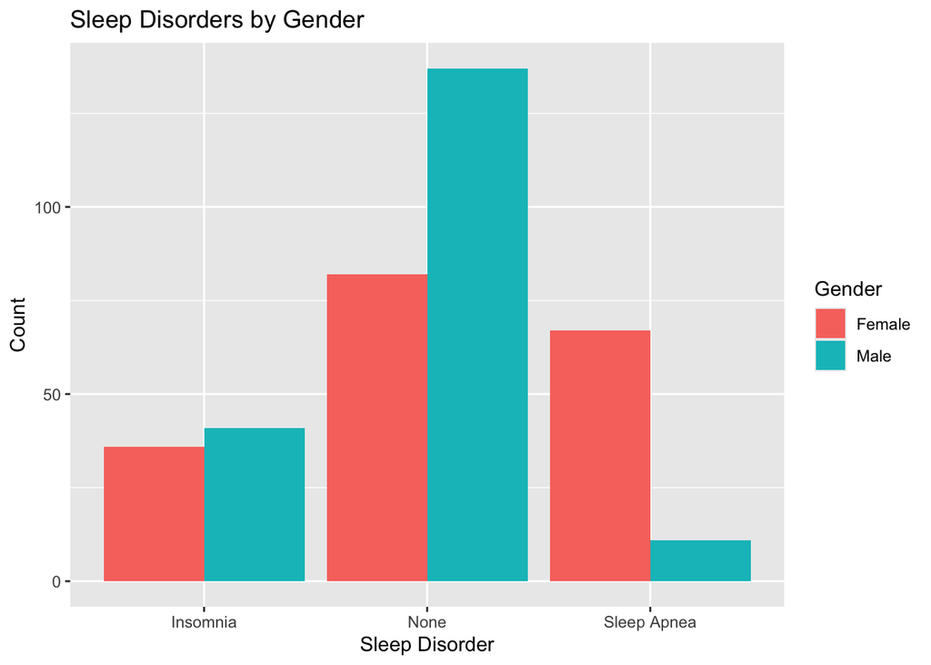

```r
ggplot(data = df, aes(x = Sleep.Disorder, fill = Gender)) +
  geom_bar(position = "dodge") +
  labs(title = "Sleep Disorders by Gender",
       x = "Sleep Disorder",
       y = "Count")
```

## Quality of Sleep by Sleep Disorder

Individuals without any sleep disorders generally have a higher median quality of sleep compared to those with insomnia.

Those with insomnia show a lower and more consistent quality of sleep, with notable outliers indicating some variability.

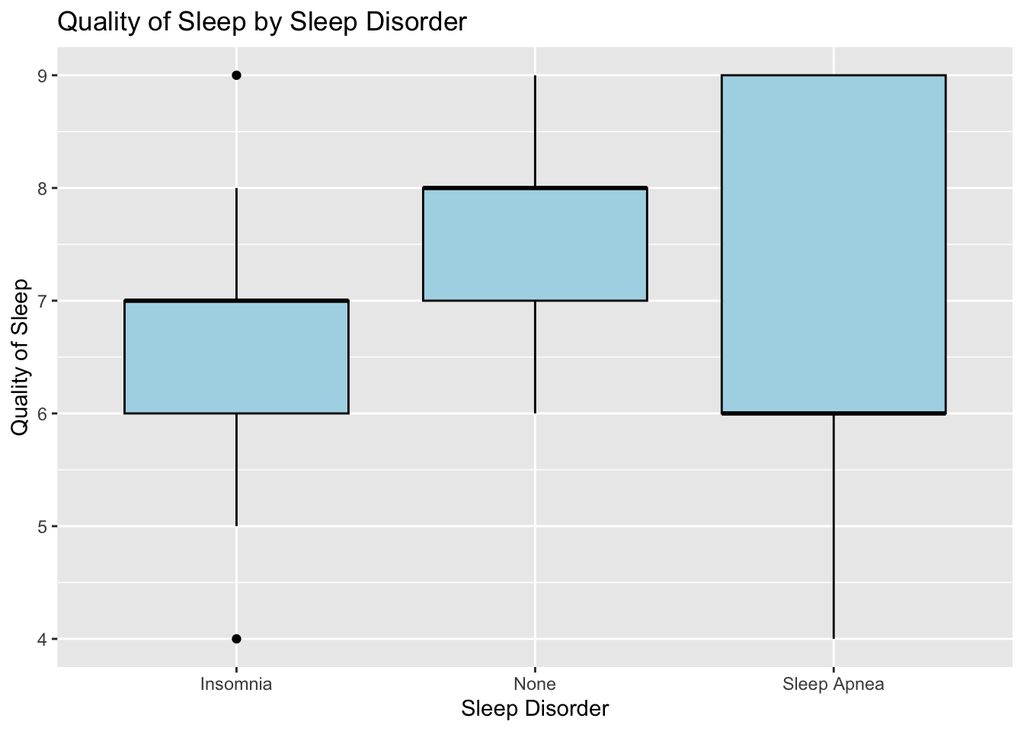

```r
ggplot(data = df, aes(x = Sleep.Disorder, y = Quality.of.Sleep)) +
  geom_boxplot(col = "black", fill = "lightblue") +
  labs(title = "Quality of Sleep by Sleep Disorder",
       x = "Sleep Disorder",
       y = "Quality of Sleep")
```